# Analisis Descriptivo Exploratorio

Angel Santiago Perez 40023-40448

12 de junio de 2019

# Punto 3

Importo bibliotecas y cargo el dataset descargado.Dicho DS fue descargado de la API de Spotify Developer seleccionando ciertos atributos (features) con la particularidad de ser de los top 50 del momentos, en los paises de habla hispana.

```r
library("GGally")
library(ggplot2)
library(tidyverse)
library(gapminder)
library(DataExplorer)

dsspotify<-read.csv("./dataset_spotify.csv")
```

Empezando a ver cierta estructura del Dataset:

### Resumen:

```r
resumen<-summary(dsspotify)

numerovariable<-ncol(dsspotify)
numeroobjetorig<-nrow(dsspotify)
variables<-colnames(dsspotify)
```

```
##        X                            cancion     popularidad
##  Min.   :  1   Calma - Remix            : 19   Min.   : 18.00
##  1st Qu.:239   Adan y Eva               : 18   1st Qu.: 75.00
##  Median :477   Desconocidos             : 18   Median : 80.00
##  Mean   :477   Ella Quiere Beber - Remix: 18   Mean   : 77.77
##  3rd Qu.:715   Amanece                  : 17   3rd Qu.: 86.00
##  Max.   :953   Culpables                : 16   Max.   :100.00
##                (Other)                  :847
##          artista                                        artista_completo
##  Bad Bunny   : 80   Bad Bunny                                   : 55
##  Anuel Aa    : 62   Paulo Londra                                : 27
##  Ozuna       : 38   Maluma                                      : 21
##  Karol G     : 36   Pedro Capó feat. Farruko                    : 19
##  Piso 21     : 34   Anuel Aa feat. Romeo Santos                 : 18
##  Paulo Londra: 33   Mau y Ricky feat. Manuel Turizo feat. Camilo: 18
##  (Other)     :670   (Other)                                     :795
##                        album                       top_pais
##  X 100PRE                 : 62   El Top 50 de Venezuela:100
##  Aura                     : 23   El Top 50 de Uruguay  : 52
##  Sueños                   : 20   El Top 50 de Paraguay : 51
##  Calma (Remix)            : 19   El Top 50 de Argentina: 50
##  Ella Quiere Beber (Remix): 18   El Top 50 de Bolivia  : 50
##  Ubuntu                   : 18   El Top 50 de Chile    : 50
##  (Other)                  :793   (Other)               :600
##      puesto       bailabilidad       energia        nota_musical
##  Min.   :  1.0   Min.   :0.3000   Min.   :0.2870   Min.   : 0.000
##  1st Qu.: 14.0   1st Qu.:0.7010   1st Qu.:0.6470   1st Qu.: 2.000
##  Median : 27.0   Median :0.7600   Median :0.7300   Median : 6.000
##  Mean   : 28.2   Mean   :0.7463   Mean   :0.6995   Mean   : 5.686
##  3rd Qu.: 40.0   3rd Qu.:0.8060   3rd Qu.:0.7830   3rd Qu.: 8.000
##  Max.   :100.0   Max.   :0.9330   Max.   :0.9740   Max.   :11.000
##
##     volumen             modo           hablado          acustico
##  Min.   :-11.420   Min.   :0.0000   Min.   :0.0281   Min.   :0.00513
##  1st Qu.: -5.574   1st Qu.:0.0000   1st Qu.:0.0593   1st Qu.:0.12600
##  Median : -4.470   Median :1.0000   Median :0.1060   Median :0.25400
##  Mean   : -4.920   Mean   :0.5467   Mean   :0.1325   Mean   :0.26899
##  3rd Qu.: -3.559   3rd Qu.:1.0000   3rd Qu.:0.1790   3rd Qu.:0.37200
##  Max.   : -1.098   Max.   :1.0000   Max.   :0.5000   Max.   :0.94000
##
##   instrumental          en_vivo        positividad        tempo
##  Min.   :0.0000000   Min.   :0.0161   Min.   :0.117   Min.   : 70.14
##  1st Qu.:0.0000000   1st Qu.:0.0863   1st Qu.:0.516   1st Qu.: 94.05
##  Median :0.0000000   Median :0.1080   Median :0.675   Median :102.06
##  Mean   :0.0019149   Mean   :0.1463   Mean   :0.626   Mean   :122.06
##  3rd Qu.:0.0000346   3rd Qu.:0.1580   3rd Qu.:0.772   3rd Qu.:159.92
##  Max.   :0.3120000   Max.   :0.8920   Max.   :0.963   Max.   :203.93
##
##     duracion      tiempo_compas          fecha
##  Min.   :125714   Min.   :3.000   2018-12-23: 62
##  1st Qu.:190005   1st Qu.:4.000   2018-12-14: 46
##  Median :210368   Median :4.000   2018-11-09: 31
##  Mean   :217604   Mean   :3.991   2018-11-02: 30
##  3rd Qu.:235284   3rd Qu.:4.000   2018-08-10: 27
##  Max.   :456940   Max.   :5.000   2019-05-10: 27
##                                   (Other)   :730
```

El DS tiene 22 variables (o columnas) y 953 ejemplos (o filas). Las variables son: (X, cancion, popularidad, artista, artista_completo, album, top_pais, puesto, bailabilidad, energia, nota_musical, volumen, modo, hablado, acustico, instrumental, en_vivo, positividad, tempo, duracion, tiempo_compas, fecha).

### Estructura

La estructura de las variables es:

```r
estructu<-str(dsspotify);
```

```
## 'data.frame':    953 obs. of  22 variables:
##  $ X               : int  1 2 3 4 5 6 7 8 9 10 ...
##  $ cancion         : Factor w/ 212 levels "¿Quien Tu Eres?",..: 30 88 8 35 160 167 56 23 207 163 ...
##  $ popularidad     : int  91 39 87 95 43 90 86 88 41 83 ...
##  $ artista         : Factor w/ 122 levels "6ix9ine","Agus Padilla",..: 96 86 95 32 58 8 84 93 58 56 ...
##  $ artista_completo: Factor w/ 183 levels "6ix9ine feat. Anuel Aa",..: 142 121 139 46 80 10 118 133 79 76 ...
##  $ album           : Factor w/ 186 levels "÷ (Deluxe)","11:11",..: 29 81 11 35 137 142 49 23 175 141 ...
##  $ top_pais        : Factor w/ 18 levels "El Top 50 de Argentina",..: 17 17 17 17 17 17 17 17 17 17 ...
##  $ puesto          : int  1 2 3 4 5 6 7 8 9 10 ...
##  $ bailabilidad    : num  0.826 0.694 0.767 0.737 0.678 0.807 0.709 0.816 0.811 0.747 ...
##  $ energia         : num  0.773 0.581 0.709 0.86 0.717 0.803 0.771 0.754 0.881 0.74 ...
##  $ nota_musical    : int  11 6 1 8 11 11 7 11 7 4 ...
##  $ volumen         : num  -4.22 -7.38 -4.47 -2.65 -5.37 ...
##  $ modo            : int  0 1 1 0 0 1 1 0 0 0 ...
##  $ hablado         : num  0.0524 0.0496 0.336 0.0593 0.245 0.126 0.166 0.111 0.0405 0.191 ...
##  $ acustico        : num  0.323 0.843 0.323 0.11 0.202 0.602 0.146 0.0361 0.183 0.0165 ...
##  $ instrumental    : num  0.00 2.12e-06 0.00 1.94e-06 0.00 8.53e-03 3.29e-06 0.00 1.48e-03 9.94e-05 ...
##  $ en_vivo         : num  0.143 0.0823 0.0676 0.0574 0.892 0.136 0.249 0.217 0.0651 0.101 ...
##  $ positividad     : num  0.761 0.664 0.72 0.656 0.654 0.706 0.709 0.533 0.649 0.552 ...
##  $ tempo           : num  126.9 107.1 172 94 82.2 ...
##  $ duracion        : int  238200 172722 258639 193227 181084 258800 204453 158400 175800 158800 ...
##  $ tiempo_compas   : int  4 4 4 4 4 4 4 4 4 4 ...
##  $ fecha           : Factor w/ 116 levels "1975-11-21","1980-06-27",..: 46 104 57 79 114 75 49 73 89 61 ...
```

## Analizando las variables

1. Diagrama de caja de los valores de, los grupo por pais de, variables numericas.
2. Diagrama de caja de la distribucion de los años registrados de los albums.
3. Diagrama de correlación entre todas la variables numericas del DS.

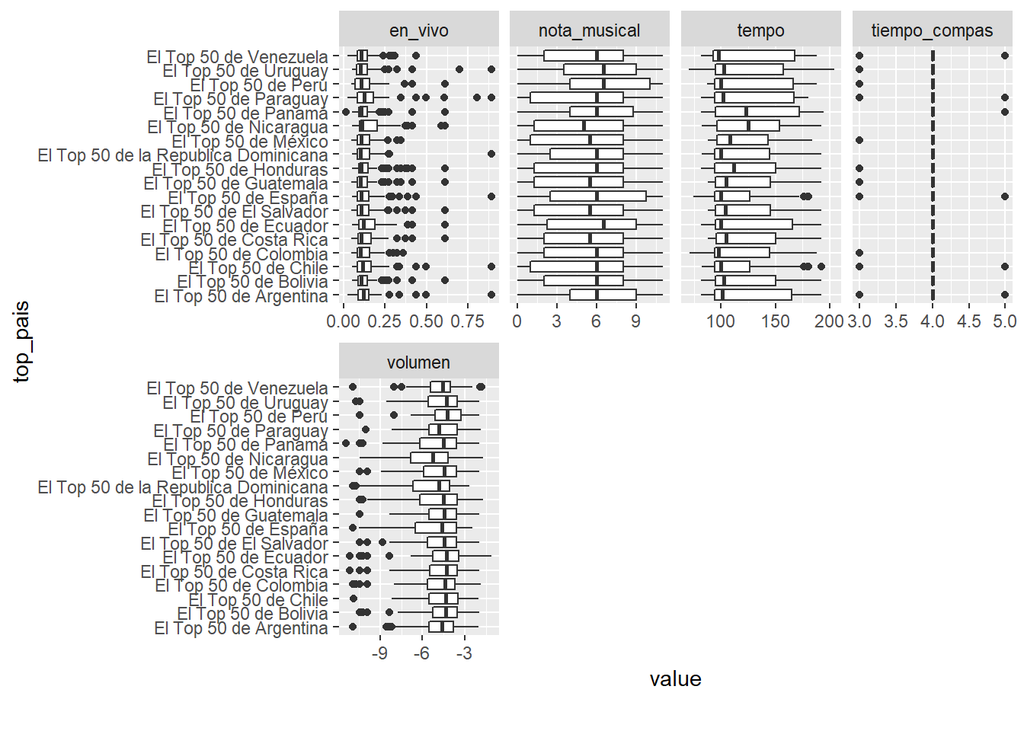

```r
cajasvariables<-plot_boxplot(
        data=dsspotify[,c("volumen","nota_musical","en_vivo","tempo","tiempo_compas", "top_pais")],
        by = "top_pais")
```

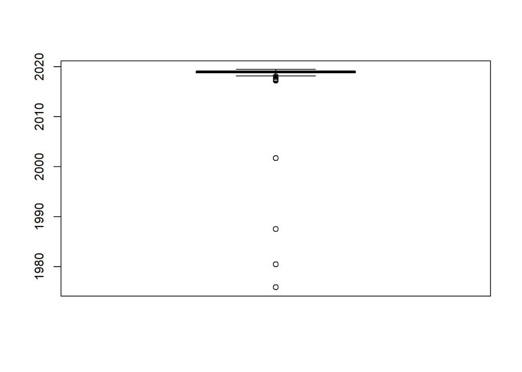

```r
cajafechas<-boxplot(as.Date(dsspotify$fecha))
```

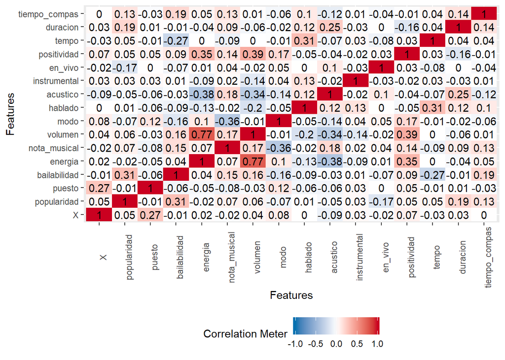

```r
correlavariables<-plot_correlation(dsspotify, maxcat = 0)
```

## Preprocesamiento

En esta seccion hago un preprocesamiento de los datos, ya que se nota que contiene datos “impuros” (como que aparecen en algunos paises puestos mayores a 50), y ademas proceso las variables que me interesan y tienen mayor correlación para mi futuro analisis.

```r
prepros1<-dsspotify %>% filter(puesto<=50)
numeroobje<-nrow(prepros1)
columnasprepro2<-c(2,4,7,8,3,9,10,14,15,18,20,12)
prepros2<-prepros1 %>% select(columnasprepro2)
```

Al final de mi preprocesamiento quedan 900 filas y 12 columnas.

# Variables

Las columnas son: (cancion, artista, top_pais, puesto, popularidad, bailabilidad, energia, hablado, acustico, positividad, duracion, volumen)

*cancion: indica el nombre de la canción que aparece en el album.*

*artista: indica el artista principal del cual produjo el album.*

*puesto: indica del 1 al 50 que puesto esta segun el ranking de cada pais.*

*top_pais: indica de que ranking es el puesto y la canción.*

*popularidad: indica que tan popular es la cancion en el pais del 1 al 100, es un porcentaje.*

*bailabilidad: indica que tan adecuada es una canción para bailar segun el ritmo del 0 al 1.*

*energia: indica que tan intenso o activo es una canción, mide el ruido y la rapidez del 0 al 1.*

*hablado: indica la presencia de voz en la canción, si es musica-canción-discurso, del 0 al 1.*

*acustico: indica que tan acustico es la canción, si contiene o no musica, del 0 al 1.*

*positividad: indica la positividad-alegria segun la valencia de la canción del 0 al 1.*

*duracion: indica la duración de la canción al reproducirse en ms.*

*volumen: indica el volumen promedio de la pista se mide en dB de -60 a 0.*

```r
head(prepros2)
```

```
##         cancion      artista             top_pais puesto popularidad
## 1 Calma - Remix   Pedro Capó El Top 50 de Uruguay      1          91
## 2          Hope     Mike Wit El Top 50 de Uruguay      2          39
## 3    Adan y Eva Paulo Londra El Top 50 de Uruguay      3          87
## 4     Con Calma Daddy Yankee El Top 50 de Uruguay      4          95
## 5     Qué pasó?      J.Beren El Top 50 de Uruguay      5          43
## 6       Secreto     Anuel Aa El Top 50 de Uruguay      6          90
##   bailabilidad energia hablado acustico positividad duracion volumen
## 1        0.826   0.773  0.0524    0.323       0.761   238200  -4.218
## 2        0.694   0.581  0.0496    0.843       0.664   172722  -7.382
## 3        0.767   0.709  0.3360    0.323       0.720   258639  -4.470
## 4        0.737   0.860  0.0593    0.110       0.656   193227  -2.652
## 5        0.678   0.717  0.2450    0.202       0.654   181084  -5.365
## 6        0.807   0.803  0.1260    0.602       0.706   258800  -4.156
```

```r
toppaises<-prepros2 %>% select(top_pais) %>% distinct(top_pais)
paises<-substring(as.character(toppaises[1:18,]), 14)
canciones<-prepros2 %>% select(cancion) %>% distinct(cancion)
artistas<-prepros2 %>% select(artista) %>% distinct(artista)
```

De este DS de Spotify de top 50 de paises hispanohablantes se evaluan: 18 paises, que son: (Uruguay, la Republica Dominicana, Perú, Paraguay, Panamá, Nicaragua, México, Honduras, Guatemala, España, El Salvador, Ecuador, Costa Rica, Colombia, Chile, Bolivia, Argentina, Venezuela). 211 canciones distintas de 121 artistas principales.

## EDA profundo

### 1)

Primero noto que hay dos etiquetas muy parecidas, Top y Popularidad. Al ver la documentación de la API noto que la popularidad de cada canción esta directamente relacionado con la cantidad de visitas-reproducciones que ha tenido dicha canción, y que ademas es calculado por algoritmo de Spotify para realizar sugerencias o recomendaciónes, a diferencia del Top, que es lo mas escuchado y puntuado (en likes) en cada pais, en este caso solo hasta los tops 50.

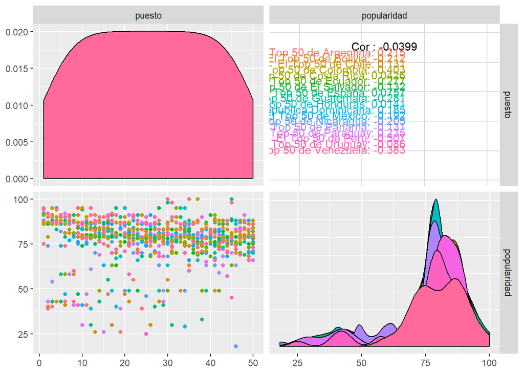

```r
grafirealgorit <- ggpairs(prepros2, mapping = aes(color = top_pais), columns =
                  colnames(prepros2[,4:5]),cardinality_threshold = 20); grafirealgorit #Top-Popul
```

En este grafico se puede ver que la gran mayoria de las canciones que estan en el top son clasificadas como populares, mientras que una pequeña cantidad que son tops no son populares o recomendadas.

### 2)

Nuevamente veo la correlación entre las variables numericas preprocesadas, lo cual simplifica la vista al intentar evaluar relaciones entre las etiquetas que fueron calculadas por el algoritmo de Spotify.

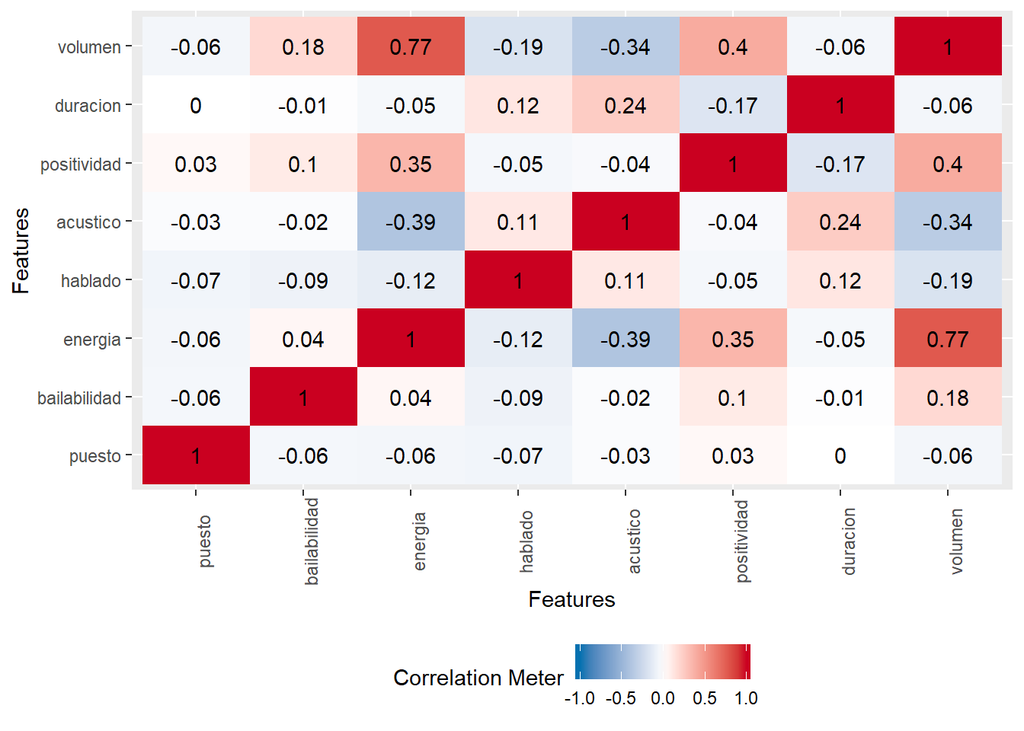

```r
correlacvariapreprose<-plot_correlation(prepros2[,-5], maxcat = 0)
```

### 3)

En este apartado se ve un grafico de pares, con cada pares de variables, el primer grafico muestra que el “top_pais” no añade valor, por lo que se prescinde de el momentanemente. Aunque se puede notar la distribución en cajas de las variables por paises.

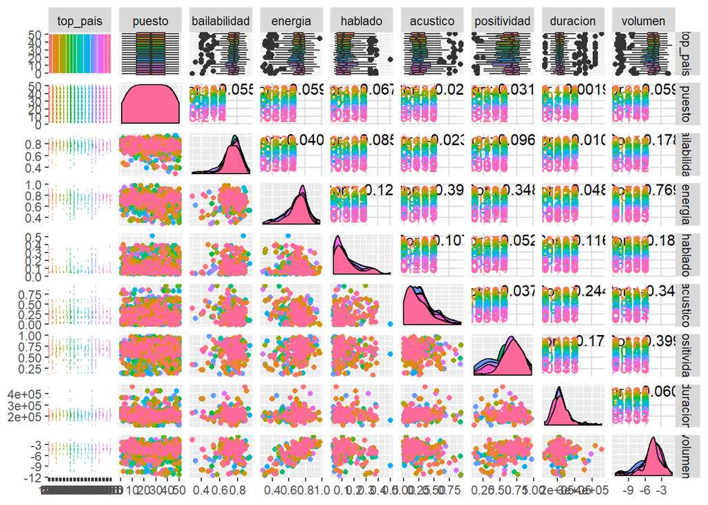

```r
grafivar <- ggpairs(prepros2, mapping = aes(color = top_pais),
                    columns = colnames(prepros2)[-c(1:2,5)],cardinality_threshold = 20); grafivar
```

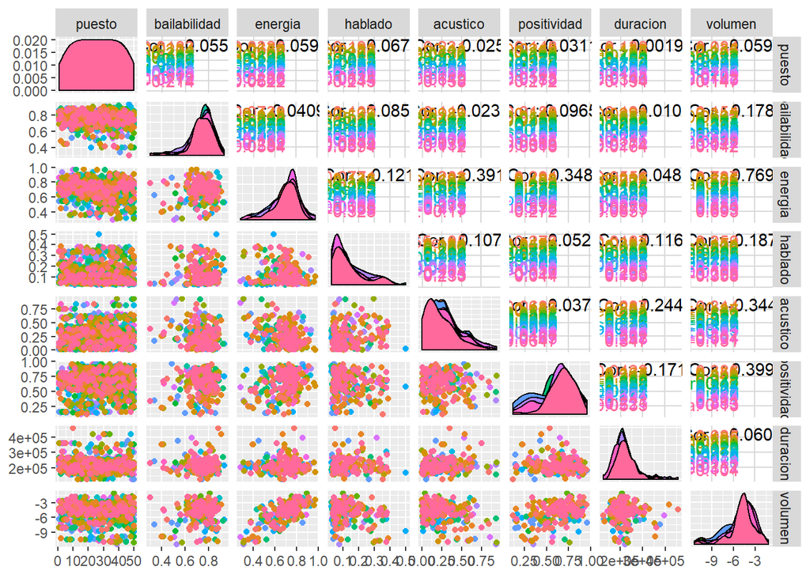

```r
grafiusar <- ggpairs(prepros2, mapping = aes(color = top_pais),
                    columns = colnames(prepros2)[c(4,6:12)],cardinality_threshold = 20); grafiusar
```

### 4)

Por ultimo se ve un histograma de artistas y canciones. Aqui se ve que tan frecuentes son algunos en total de todos los tops. Lo que significa que no todos los/las artistas/canciones son excluyentes de un puesto/pais.

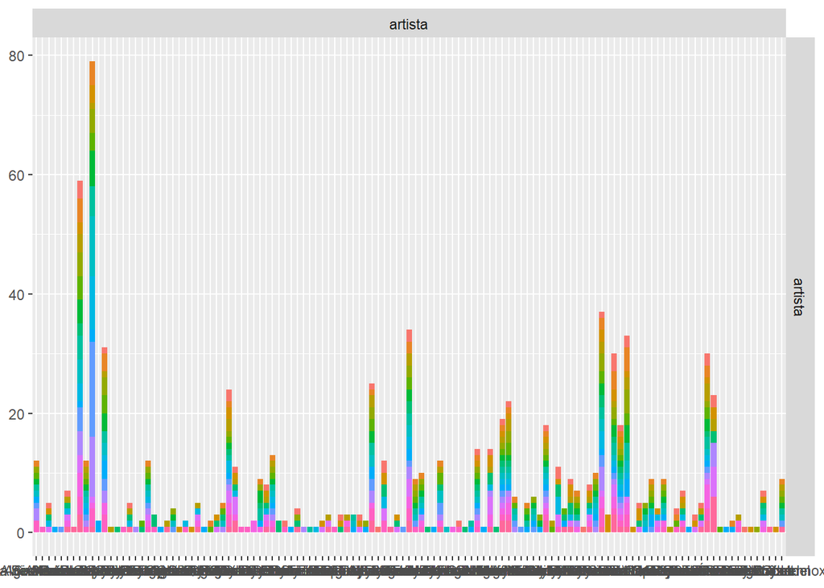

```r
grafiartishisto <- ggpairs(prepros2, mapping = aes(color = top_pais),
                     columns = colnames(prepros2)[c(2)],cardinality_threshold = 300); grafiartishisto
```

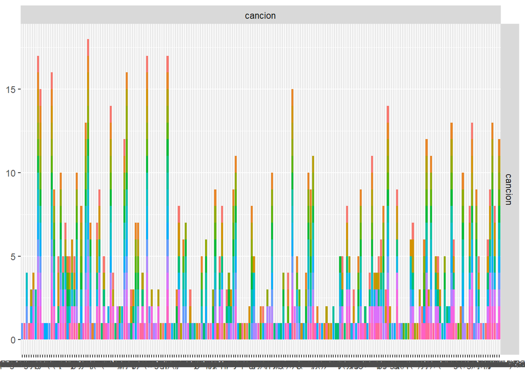

```r
graficanchisto <- ggpairs(prepros2, mapping = aes(color = top_pais),
                      columns = colnames(prepros2)[c(1)],cardinality_threshold = 300); graficanchisto
```

Aqui se puede notar, mejor, que mayormente las canciones se repiten en varios puestos del top, y que la no hay gran distinción entre canciones/artistas por variación de paises.

[figure not shown]

```r
grafiartista<-plot_scatterplot(prepros2[1:5], by = "artista")
```

```r
if(0==1)
{
  graficancion<-plot_scatterplot(prepros2[1:5], by = "cancion")
  write.csv(prepros2,"dspreprocesado.csv")
}
```